# StatComp Project 1: 3D printer materials estimation

JIAJUN LI (s2265910)

# 1 The data

The filament1 data frame is

```
## # A tibble: 86 × 5
##    Index Date       Material  CAD_Weight Actual_Weight
##    <dbl> <date>     <chr>          <dbl>         <dbl>
##  1     1 2017-12-29 Neon pink         33            38
##  2     2 2017-12-29 Green             40            43
##  3     3 2017-12-30 Green             20            23
##  4     4 2017-12-30 Green             44            47
##  5     5 2017-12-30 Green             18            19
##  6     6 2017-12-30 Green              3             3
##  7     7 2017-12-31 Green              5             5
##  8     8 2018-01-01 Green             35            37
##  9     9 2018-01-02 Green             19            20
## 10    10 2018-01-03 Green              8             9
## # ℹ 76 more rows
```

The plot of Variability of Actual Weight Across Materials. From the plot, we can see that the height of red material’s box is taller than others showing that the variability of red material is greatest. The height of Magenta and Neon pink is lower than others showing that the variability of Magenta and Neon pink material is least. The variability of black and green material are similar and the varibility of neon blue is greater than black and green material.

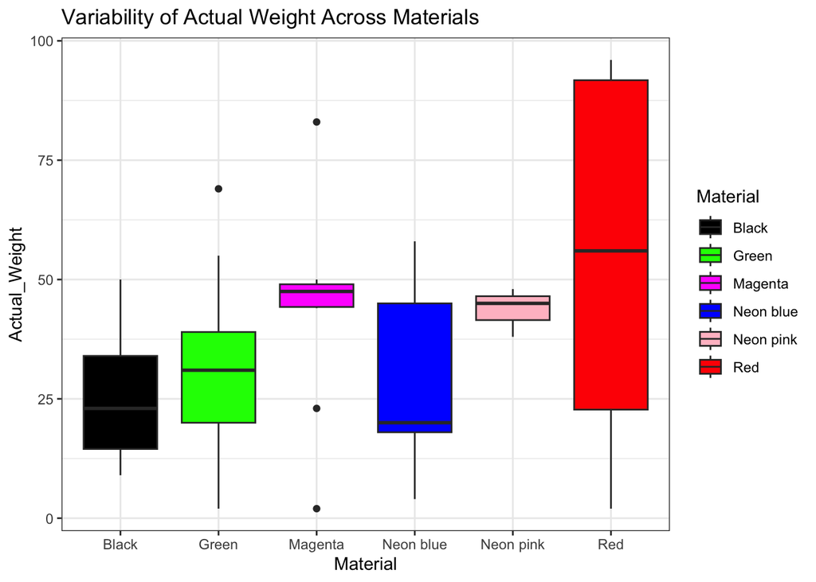

From the graph below, we can see that the Actual Weight tends to increase as the CAD Weight increases. Based on the graph, it can be inferred that there is a general agreement between CAD Weight and Actual Weight across the materials. From this graph, it is also possible to see that the variability of red material is greatest. The variability of CAD weight in the middle is greater than two tails.

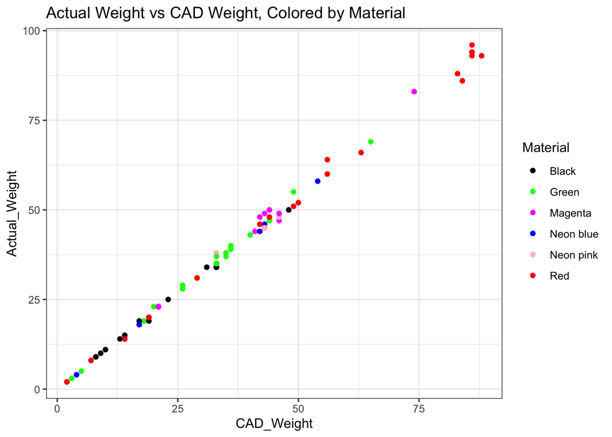

# 2 Classical estimation

The 90% confidence intervals is

| CI | lower | expectation | upper |
| --- | --- | --- | --- |
| beta1 A | -0.300655959071511 | -0.0893297402084727 | 0.121996478654565 |
| beta2 A | 1.06947002237021 | 1.07920922260985 | 1.0889484228495 |
| beta3 A | -2.47146739471623 | -1.90378021138596 | -1.33609302805568 |
| beta4 A | 0.0410234967943418 | 0.0556948585551916 | 0.0703662203160415 |
| beta1 B | -0.221530697224056 | -0.161284523914674 | -0.101038350605292 |
| beta2 B | 1.07516088111892 | 1.08285908837034 | 1.09055729562175 |
| beta3 B | -98.0486474731638 | -13.5014797035868 | 71.0456880659903 |
| beta4 B | -6.86446360794593 | -6.61360179709205 | -6.36273998623817 |

The confidence interval for a parameter estimate is a range of values that is likely to contain the true value of the parameter. The width of the confidence interval gives us an idea of the precision of the estimate: narrower intervals suggest more precise estimates. From the table above, we can see 4 beta value with two different models A and B.

Beta1 model A: The confidence interval ranges from -0.3006 to 0.1219, with the expectation at -0.0893. The width of this interval is 0.4225, which suggests some uncertainty in the estimate of this parameter.

Beta1 model B: The CI ranges from -0.2215 to -0.1010, with the expectation at -0.1613, and the width is 0.1205, which shows a reasonable amount of uncertainty.

Beta2 model A: The CI is from 1.0695 to 1.0889, with the expectation at 1.0792, and a narrow width of 0.0194. This indicates a precise estimate of the parameter.

Beta2 model B: The CI is from 1.0752 to 1.0906, with the expectation at 1.0829, and a narrow width of 0.0154, indicating a precise estimate.

Beta3 model A: This has a CI from -2.4715 to -1.3360, expectation at -1.9038, and a width of 1.1355. The relatively large width indicates a higher uncertainty in this estimate.

Beta3 model B: This has a CI from -98.0486 to 71.0457, expectation at -13.5015, and a very wide width of 169.0943. This incredibly large width indicates extreme uncertainty and suggests that the parameter may not be well-estimated or that the model is not appropriate.

Beta4 model A: The CI is from 0.0410 to 0.0704, with the expectation at 0.0557, and the width is 0.0294, indicating moderate precision.

Beta4 model B: The CI is from -6.8645 to -6.3627, with the expectation at -6.6136, and a width of 0.5018, indicating some uncertainty but not as extreme as beta3 model B.

In summary, Model A seems to provide more precise and potentially more reliable parameter estimates than Model B, judging by the width of the confidence intervals. Model B, particularly with its beta3 parameter, shows signs that it may not be the best model for the data.

# 3 Bayesian estimation

The $\mu$ of mode is

| theta | mu |
| --- | --- |
| theta1 | -0.1007081 |
| theta2 | 1.0800213 |
| theta3 | -2.9817858 |
| theta4 | -6.7585702 |

The covariance matrix S is

| beta | theta1 | theta2 | theta3 | theta4 |
| --- | --- | --- | --- | --- |
| theta1 | 0.00830224415036667 | -0.000343320252021368 | 0.0302722790560285 | -0.00428850913871761 |
| theta2 | -0.000343320252021368 | 2.99588335576416e-05 | -0.00149285575810944 | 0.00021180146219596 |
| theta3 | 0.0302722790560285 | -0.00149285575810944 | 1.06290825428537 | -0.123597097122869 |
| theta4 | -0.00428850913871761 | 0.00021180146219596 | -0.123597097122869 | 0.0454008903416237 |

The empirical weighted CDFs together with the unweighted CDFs for each parameter is

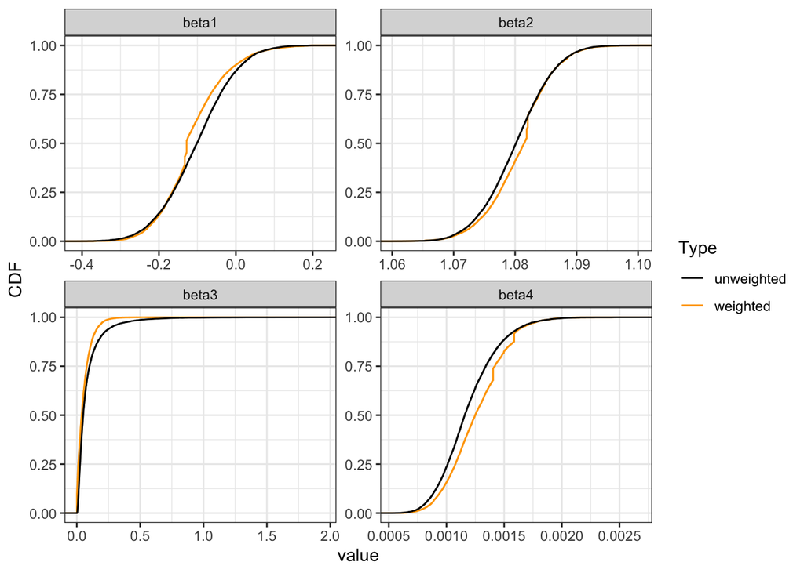

The resulting 90% credible intervals is

| beta | lower | upper |
| --- | --- | --- |
| beta1 | -0.2401574 | 0.0400799 |
| beta2 | 1.0717229 | 1.0890674 |
| beta3 | 0.0010721 | 0.1694644 |
| beta4 | 0.0008720 | 0.0016630 |

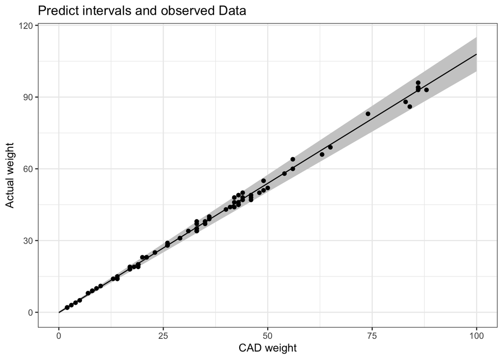

From the graph, the prediction intervals agree with the observed data, since nearly all the observed points fall in the prediction intervals. Additionally, the functional form of the standard deviation model seems to fit the data well.

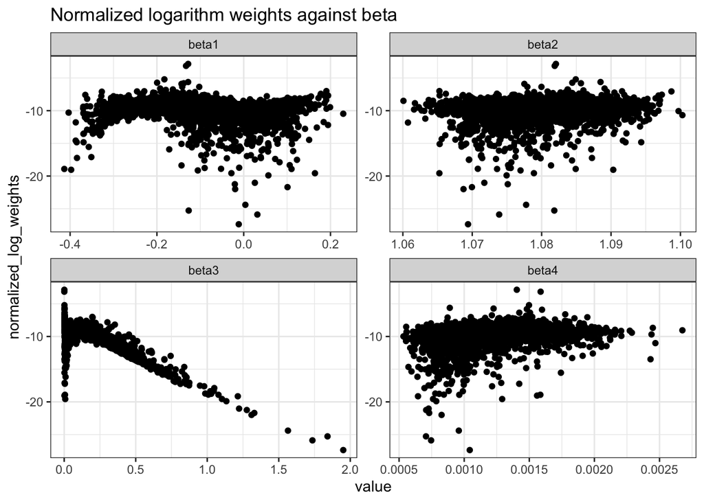

Here, we plot the normalized logarithm weights against each $\beta_i$ parameter. From the graph, we can see that the weights for $\beta_1, \beta_2$ and $\beta 4$ are nearly spread equally in the given range of value. However, for $\beta_3$, some very large weights are generated for some small values, which shows that the Gaussian approximation is worse for $\beta_3$. This also shows a bad Gaussian approximation for $\theta_3$. Thus, Gaussian approximation’s density might have large difference with the exact posterior density.

# 4 Code appendix

```r
#' JIAJUN LI, s2265910
#' Add your own function definitions on this file.

#' Log-Exponential density
#'
#' Compute the density or log-density for a Log-Exponential (LogExp)
#' distribution
#'
#' @param x vector of quantiles
#' @param rate vector of rates
#' @param log logical; if TRUE, the log-density is returned

dlogexp <- function(x, rate = 1, log = FALSE) {
  result <- log(rate) + x - rate * exp(x)
  if (!log) {
    exp(result)
  }
  result
}

#' Log-Sum-Exp
#'
#' Convenience function for computing log(sum(exp(x))) in a
#' numerically stable manner
#'
#' @param x numerical vector

log_sum_exp <- function(x) {
  max_x <- max(x, na.rm = TRUE)
  max_x + log(sum(exp(x - max_x)))
}

#' neg_log_like
#'
#' The function that calculate the negative log likelihood for
#' specified model
#'
#' @param beta model parameters
#' @param data a data.frame containing the required variables
#' @param model A or B model
#'
#' @return the negative log likelihood for specified model
neg_log_like <- function(beta, data, model){
  x <- data$CAD_Weight
  # initialize the negative sum
  negative_sum <- 0
  y <- data$Actual_Weight
  if (model == "A") {
    mean_A <- beta[1] + beta[2] * x
    sd_A <- sqrt(exp(beta[3] + beta[4] * x))
    negative_sum <- -sum(dnorm(x = y, mean = mean_A, sd = sd_A, log = TRUE))
  } else if (model == "B") {
    mean_B <- beta[1] + beta[2] * x
    sd_B <- sqrt(exp(beta[3]) + exp(beta[4] )* (x^2))
    negative_sum <- -sum(dnorm(x = y, mean = mean_B, sd = sd_B, log = TRUE))
  }
  return(negative_sum)
}

#' filament1_estimate
#'
#' The function that uses the R built in function optim()
#' and neg_log_like() to estimate the two models A and B
#' using the filament1 data.
#'
#' @param data a data.frame with the same variables as the filament1 data set
#' @param model model choice (either A or B)
#'
#' @return par (the best set of parameters found) and
#' hessian(the estimate of the Hessian at the solution found)
filament1_estimate <- function(data = filament1, model){
  # initialize the initial values for specified model
  initial <- c(0, 0, 0, 0)
  if (model == "A") {
    # change the initial values for model A
    initial <- c(-0.1, 1.07, -2, 0.05)
  } else if (model == "B") {
    # change the initial values for model B
    initial <- c(-0.15, 1.07, -13.5, -6.5)
  }
  opt <- optim(
    initial,
    neg_log_like,
    data = filament1, model = model,
    method = "BFGS",
    hessian = TRUE
  )
  if (opt$convergence != 0){
    print("Convergence is not zero")
  }
  return(list("par" = opt$par, "hessian" = opt$hessian))
}


#' log_prior_density
#'
#' The function that evaluate the logarithm of the joint prior density
#' p(θ) for the four θi parameters.
#'
#' @param theta theta is the θ parameter vector
#' @param params the vector of γ parameters
#'
#' @return the logarithm of the joint prior density
#' p(θ) for the four θi parameters.
log_prior_density <- function(theta, params){
  log_theta1 <- dnorm(theta[1], mean = 0, sd = sqrt(params[1]), log = TRUE)
  log_theta2 <- dnorm(theta[2], mean = 1, sd = sqrt(params[2]), log= TRUE)
  log_theta3 <- dlogexp(theta[3], rate = params[3], log = TRUE)
  log_theta4 <- dlogexp(theta[4], rate = params[4], log = TRUE)
  # the logarithm of the joint prior density of four theta
  joint <- log_theta1 + log_theta2 + log_theta3 + log_theta4
  return(joint)
}

#' log_like
#'
#' The function that evaluates the observation log-likelihood p(y|θ).
#'
#' @param theta theta is the θ parameter vector
#' @param x CAD weights
#' @param y Actual weights
#'
#' @return the observation log-likelihood p(y|θ)
log_like <- function(theta, x, y){
  mean_obs <- theta[1] + theta[2] * x
  sd_obs <- sqrt(exp(theta[3]) + exp(theta[4]) * x^2)
  log_like <- sum(dnorm(x = y, mean = mean_obs, sd = sd_obs, log =TRUE))
  return(log_like)
}

#' log_posterior_density
#'
#' The function that evaluates the logarithm of the posterior density p(θ|y),
#'  apart from some unevaluated normalisation constant.
#' @param theta theta is the θ parameter vector
#' @param x CAD weights
#' @param y Actual weights
#' @param params the vector of γ parameters
#'
#' @return the logarithm of the posterior density p(θ|y)
log_posterior_density <- function(theta, x, y, params) {
  log_prior_density(theta, params) + log_like(theta, x, y)
}

#' posterior mode
#'
#' The function that find the mode µ of the log-posterior-density and
#' evaluates the Hessian at the mode as well as
#' the inverse of the negated Hessian, S.
#' @param theta_start the start vector in optim() function
#' @param x CAD weights
#' @param y Actual weights
#' @param params the vector of γ parameters
#'
#' @return the mode µ of the log-posterior-density and
#' evaluates the Hessian at the mode as well as
#' the inverse of the negated Hessian, S.
posterior_mode <- function(theta_start, x, y, params){
  opt <- optim(
    theta_start,
    log_posterior_density,
    x = x, y = y, params = params,
    hessian = TRUE,
    # to do maximisation instead of minimisation
    control = list(fnscale = -1)
  )
  if (opt$convergence != 0){
    print("Convergence is not zero")
  }
  return(list(mode = opt$par, hessian = opt$hessian, S = solve(-opt$hessian)))
}

#' do_importance
#'
#' The function that find beta1, beta2, beta3, beta4, log_weights,
#' containing the βi samples and normalised log-importance-weights.
#'
#' @param N the number of samples to generate
#' @param mu the mean vector for the importance distribution
#' @param S the covariance matrix
#' @param x CAD weights
#' @param y Actual weights
#' @param params the vector of γ parameters
#'
#' @return a data.frame with beta1, beta2, beta3, beta4, log_weights,
#' containing the βi samples and normalised log-importance-weights.
do_imprtance <- function(N, mu, S, x, y, params){
  # get sample by rmvnorm
  sample <- rmvnorm(N, mu, S)
  # initialize the log posterior list
  log_posterior_list = 1:N
  for (i in 1:N) {
    log_posterior_list[i] <- log_posterior_density(sample[i,], x, y, params)
  }
  # get density of the posterior mode
  pm <- dmvnorm(sample, mean = mu, sigma = S, log = TRUE)
  # get logarithm weights
  log_weights <- log_posterior_list - pm
  # normalize the logarithm weights
  normalized_log_weights <- log_weights - log_sum_exp(log_weights)
  beta1 <- sample[,1]
  beta2 <- sample[,2]
  beta3 <- exp(sample[,3])
  beta4 <- exp(sample[,4])
  data.frame(beta1, beta2, beta3, beta4, normalized_log_weights)
}
```

```r
#' make_CI
#'
#' The function that find the weighted quantile of given data
#'
#' @param x numeric vector whose sample quantiles are wanted
#' @param weights numeric vector of non-negative weights
#' @param probs numeric vector of probabilities with values in [0,1]
#'
#' @return a 1-row, 2-column data.frame with lower and upper quantile
make_CI <- function(x, weights, probs){
  wq <- wquantile(x, probs = probs, weights = weights)
  data.frame(lower = wq[1], upper = wq[2])
}
#' wquantile
#'
#' Calculates empirical sample quantiles with optional weights, for given probabilities.
#' Like in quantile(), the smallest observation corresponds to a probability of 0 and the largest to a probability of 1.
#' Interpolation between discrete values is done when type=7, as in quantile().
#' Use type=1 to only generate quantile values from the raw input samples.
#'
#' @param x numeric vector whose sample quantiles are wanted
#' NA and NaN values are not allowed in numeric vectors unless na.rm is TRUE
#' @param probs numeric vector of probabilities with values in [0,1]
#' @param na.rm logical; if true, any NA and NaN's are removed from x before the quantiles are computed
#' @param type numeric, 1 for no interpolation, or 7, for interpolated quantiles. Default is 7
#' @param weights    numeric vector of non-negative weights, the same length as x, or NULL. The weights are normalised to sum to 1. If NULL, then wquantile(x) behaves the same as quantile(x), with equal weight for each sample value

wquantile <- function (x, probs = seq(0, 1, 0.25), na.rm = FALSE, type = 7,
                       weights = NULL, ...)
{
  if (is.null(weights) || (length(weights) == 1)) {
    weights <- rep(1, length(x))
  }
  stopifnot(all(weights >= 0))
  stopifnot(length(weights) == length(x))
  if (length(x) == 1) {
    return(rep(x, length(probs)))
  }
  n <- length(x)
  q <- numeric(length(probs))
  reorder <- order(x)
  weights <- weights[reorder]
  x <- x[reorder]
  wecdf <- pmin(1, cumsum(weights)/sum(weights))
  if (type == 1) {
  }
  else {
    weights2 <- (weights[-n] + weights[-1])/2
    wecdf2 <- pmin(1, cumsum(weights2)/sum(weights2))
  }
  for (pr_idx in seq_along(probs)) {
    pr <- probs[pr_idx]
    if (pr <= 0) {
      q[pr_idx] <- x[1]
    }
    else if (pr >= 1) {
      q[pr_idx] <- x[n]
    }
    else {
      if (type == 1) {
        j <- 1 + pmax(0, pmin(n - 1, sum(wecdf <= pr)))
        q[pr_idx] <- x[j]
      }
      else {
        j <- 1 + pmax(0, pmin(n - 2, sum(wecdf2 <= pr)))
        g <- (pr - c(0, wecdf2)[j])/(wecdf2[j] - c(0,
                                                   wecdf2)[j])
        q[pr_idx] <- (1 - g) * x[j] + g * x[j + 1]
      }
    }
  }
  q
}

#' Compute empirical weighted cumulative distribution
#'
#' Version of `ggplot2::stat_ecdf` that adds a `weights` property for each
#' observation, to produce an empirical weighted cumulative distribution function.
#' The empirical cumulative distribution function (ECDF) provides an alternative
#' visualisation of distribution. Compared to other visualisations that rely on
#' density (like [geom_histogram()]), the ECDF doesn't require any
#' tuning parameters and handles both continuous and discrete variables.
#' The downside is that it requires more training to accurately interpret,
#' and the underlying visual tasks are somewhat more challenging.
#'
# @inheritParams layer
# @inheritParams geom_point
#' @param na.rm If `FALSE` (the default), removes missing values with
#'    a warning.  If `TRUE` silently removes missing values.
#' @param n if NULL, do not interpolate. If not NULL, this is the number
#'   of points to interpolate with.
#' @param pad If `TRUE`, pad the ecdf with additional points (-Inf, 0)
#'   and (Inf, 1)
#' @section Computed variables:
#' \describe{
#'   \item{x}{x in data}
#'   \item{y}{cumulative density corresponding x}
#' }
#' @seealso wquantile
#' @export
#' @examples
#' library(ggplot2)
#'
#' n <- 100
#' df <- data.frame(
#'   x = c(rnorm(n, 0, 10), rnorm(n, 0, 10)),
#'   g = gl(2, n),
#'   w = c(rep(1/n, n), sort(runif(n))^sqrt(n))
#' )
#' ggplot(df, aes(x, weights = w)) + stat_ewcdf(geom = "step")
#'
#' # Don't go to positive/negative infinity
#' ggplot(df, aes(x, weights = w)) + stat_ewcdf(geom = "step", pad = FALSE)
#'
#' # Multiple ECDFs
#' ggplot(df, aes(x, colour = g, weights = w)) + stat_ewcdf()
#' ggplot(df, aes(x, colour = g, weights = w)) +
#'   stat_ewcdf() +
#'   facet_wrap(vars(g), ncol = 1)

stat_ewcdf <- function(mapping = NULL, data = NULL,
                       geom = "step", position = "identity",
                       ...,
                       n = NULL,
                       pad = TRUE,
                       na.rm = FALSE,
                       show.legend = NA,
                       inherit.aes = TRUE) {
  ggplot2::layer(
    data = data,
    mapping = mapping,
    stat = StatEwcdf,
    geom = geom,
    position = position,
    show.legend = show.legend,
    inherit.aes = inherit.aes,
    params = list(
      n = n,
      pad = pad,
      na.rm = na.rm,
      ...
    )
  )
}


#' @title StatEwcdf ggproto object
#' @name StatEwcdf
#' @rdname StatEwcdf
#' @aliases StatEwcdf
#' @format NULL
#' @usage NULL
#' @export
#' @importFrom ggplot2 aes after_stat has_flipped_aes Stat
NULL

StatEwcdf <- ggplot2::ggproto(
  "StatEwcdf", ggplot2::Stat,
  required_aes = c("x|y", "weights"),
  dropped_aes = c("weights"),

  default_aes = ggplot2::aes(y = ggplot2::after_stat(y)),

  setup_params = function(data, params) {
    params$flipped_aes <-
      ggplot2::has_flipped_aes(data,
                               params,
                               main_is_orthogonal = FALSE,
                               main_is_continuous = TRUE)

    has_x <- !(is.null(data$x) && is.null(params$x))
    has_y <- !(is.null(data$y) && is.null(params$y))
    if (!has_x && !has_y) {
      rlang::abort("stat_ewcdf() requires an x or y aesthetic.")
    }
    has_weights <- !(is.null(data$weights) && is.null(params$weights))
    #    if (!has_weights) {
    #      rlang::abort("stat_ewcdf() requires a weights aesthetic.")
    #    }
```

```r
    params
  },

  compute_group = function(data, scales, n = NULL, pad = TRUE, flipped_aes = FALSE) {
    data <- flip_data(data, flipped_aes)
    # If n is NULL, use raw values; otherwise interpolate
    if (is.null(n)) {
      x <- unique(data$x)
    } else {
      x <- seq(min(data$x), max(data$x), length.out = n)
    }

    if (pad) {
      x <- c(-Inf, x, Inf)
    }
    if (is.null(data$weights)) {
      data_ecdf <- ecdf(data$x)(x)
    } else {
      data_ecdf <-
        spatstat.geom::ewcdf(
          data$x,
          weights = data$weights / sum(abs(data$weights))
        )(x)
    }

    df_ecdf <- vctrs::new_data_frame(list(x = x, y = data_ecdf), n = length(x))
    df_ecdf$flipped_aes <- flipped_aes
    ggplot2::flip_data(df_ecdf, flipped_aes)
  }
)
```